# 政治学方法論 I：課題10の解答例

矢内 勇生

December 10, 2014

## 準備

ggplot2を読み込んでおく。

```r
require(ggplot2)
## Mac で日本語を使う場合、以下のコメントを外して実行
# theme_set(theme_gray(base_size=12, base_family="HiraKakuProN-W3"))
```

## 問1

### 問1-1

この問題の尤度関数は、 $L(\theta) = \binom{10}{3}\theta^7 (1-\theta)^3$ と書くことができる。

これは、二項分布の確率質量関数そのものである。 したがって、尤度を求めるのにも、二項分布の関数 `dbinom()` を利用することができる。

自分で関数を定義する場合、定数倍は無視してかまわないので、

```r
lik.1 <- function(theta){
    likelihood <- theta^7 * (1 - theta)^3
    return(likelihood)
}
```

のようにすればよい。

$\theta$の取りうる範囲は$(0, 1)$なので、この範囲について尤度関数を図示すると、次のようになる。

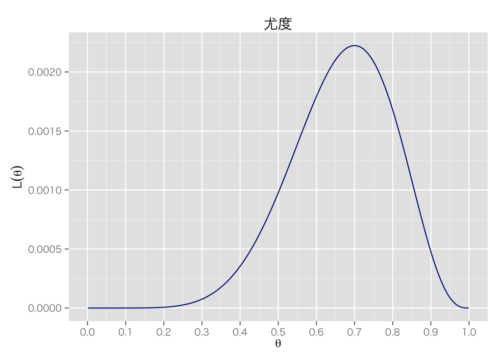

```r
## ggplot2 で図示するために、データフレームを作る
## thetaの範囲は厳密にいうと(0, 1)でないが、図示するには十分
df1 <- data.frame(theta = seq(0.001, 0.999, length=1000))
## それぞれのtheta の尤度を計算する
df1$likelihood <- lik.1(df1$theta)
## または、
# df1$likelihood <- dbinom(x=7, size=10, prob=df1$theta)
## ggplot でグラフを作る
p1.1 <- ggplot(df1, aes(x=theta, y=likelihood)) + geom_line(color="darkblue") +
    scale_x_continuous(breaks=seq(0, 1, by=.1)) +
    labs(x=expression(theta), y=expression(L(theta)), title="尤度")
print(p1.1)
```

### 問1-2

定数項を省くと、対数尤度は、 $\log L(\theta) = 7\log \theta + 3 \log (1-\theta)$ となる。

既に$\theta \in (0, 1)$の尤度の値を計算したので、その値の自然対数を`log()`で計算し、対数尤度関数を図示する。

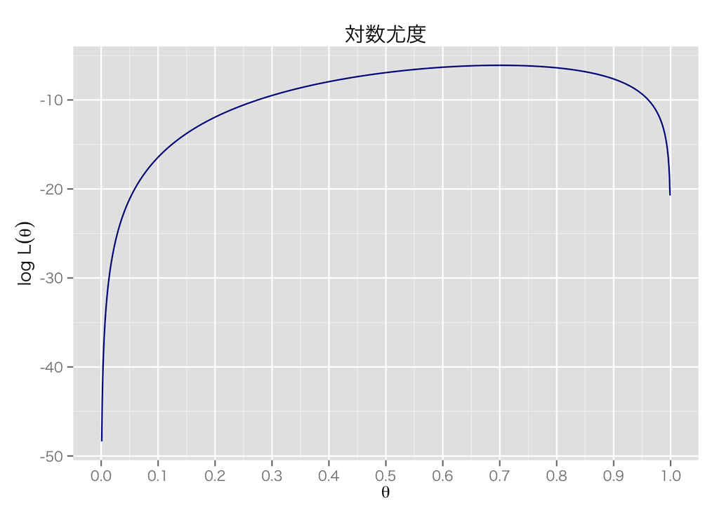

```r
df1$log.likelihood <- log(df1$likelihood)
p1.2 <- ggplot(df1, aes(x=theta, y=log.likelihood)) + geom_line(color="darkblue") +
    scale_x_continuous(breaks=seq(0, 1, by=.1)) +
    labs(x=expression(theta), y=expression(paste("log ",L(theta))), title="対数尤度")
print(p1.2)
```

### 問1-3

この問題のスコア関数は、 $S(\theta) = \frac{d}{d \theta} \log L(\theta) = \frac{7}{\theta} -\frac{3}{1-\theta}$ である。$S(\theta)=0$ を解くと、最尤推定値 $\hat{\theta} = \frac{7}{10} = 0.7$ を得る。 上に示したグラフ（尤度関数、対数尤度関数とも）からも、$\theta=0.7$で尤度が最大になることが確認できる。

### 問1-4

$I(\theta)$を得るために、対数尤度関数を2回微分してマイナス1をかけると、 $I(\theta) = -\frac{d^2}{d \theta^2} \log L(\theta) = \frac{7}{\theta^2} + \frac{3}{(1-\theta)^2}$ となる。したがって、フィッシャー情報量は、 $I(\hat{\theta}) = \frac{7}{0.7^2} + \frac{3}{(1-0.7)^2} \approx 47.62$ である。

### 問1-5

標準化した尤度関数 $L(\theta)/L(\hat{\theta})$ がある値 $c$ 以上をとる確率を考えると、 $\mathrm{Pr}\left( \frac{L(\theta)}{L(\hat{\theta})} > c\right) = \mathrm{Pr}( W < -2\log c) = \mathrm{Pr}(\chi_1^2 < -2 \log c)$ となる。ただし、$W=2\log[L(\hat{\theta})/L(\theta)]$はWilkの尤度比統計量で、$W$は自由度1のカイ二乗分布に従う。

ここで、$\chi_1^2$ の $100(1-\alpha)$ パーセンタイル点を $\kappa_{1-\alpha}$ とし、 $c = \exp \left(-\frac{1}{2} \kappa_{1-\alpha} \right)$ とすると、 $\mathrm{Pr}\left( \frac{L(\theta)}{L(\hat{\theta})} > c\right) = \mathrm{Pr}(\chi_1^2 < \kappa_{1-\alpha}) = 1 - \alpha$ となる。

したがって、90%信頼区間は $\alpha=0.1$、95%信頼区間は $\alpha=0.05$ を使って考えればよい。 $\kappa_{1-\alpha}$ の値はRで求めることができる。

```r
(kappa.90 <- qchisq(p=0.9, df=1))  ## 90パーセンタイル
```

```
## [1] 2.706
```

```r
(kappa.95 <- qchisq(p=0.95, df=1)) ## 95パーセンタイル
```

```
## [1] 3.841
```

$c$ の値もRを使って求めると、

```r
(cutoff.10 <- exp(-(1/2)*kappa.90))
```

```
## [1] 0.2585
```

```r
(cutoff.05 <- exp(-(1/2)*kappa.95))
```

```
## [1] 0.1465
```

と、なる。

したがって、90%信頼区間、95%信頼区間に相当する尤度区間はそれぞれ、 $\left\{\theta: \frac{L(\theta)}{L(\hat{\theta})} > 0.26 \right\},$ $\left\{\theta: \frac{L(\theta)}{L(\hat{\theta})} > 0.15 \right\}$ と、なる。

これらの条件を満たす $\theta$ の範囲を、Rで探してみよう。 まず、尤度を正規化 (normalize) する。

```r
df1$likelihood.nml <- df1$likelihood/lik.1(0.7)
```

次に、90%信頼区間に相当する $\theta$の範囲を探す。 上の結果より、正規化された尤度がcutoff.10$\approx 0.26$より大きい範囲の $\theta$ をみつければよい。

```r
## 指定した尤度区間に含まれるthetaを取り出す
theta.90 <- df1$theta[df1$likelihood.nml > cutoff.10]
## 指定した尤度区間に含まれるthetaの最小値と最大値を見つける
(lb.90 <- min(theta.90))
```

```
## [1] 0.4426
```

```r
(ub.90 <- max(theta.90))
```

```
## [1] 0.8911
```

したがって、90%信頼区間に相当する尤度区間は、おおよそ (0.44, 0.89) である。 これを図示しよう。

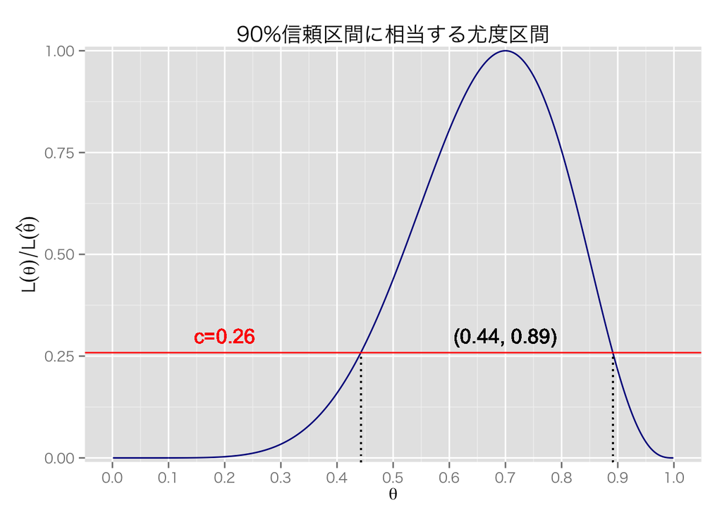

```r
p.1.5.90 <- ggplot(df1, aes(x=theta, y=likelihood.nml)) +
    geom_line(color="darkblue") +
    scale_x_continuous(breaks=seq(0, 1, by=.1)) +
    scale_y_continuous(expand=c(0, 0), limits=c(-0.01,1.01)) +
    geom_hline(yintercept=cutoff.10, color="red") +
    geom_segment(aes(x=lb.90, y= -0.01, xend=lb.90, yend=cutoff.10), linetype="dotted") +
    geom_segment(aes(x=ub.90, y= -0.01, xend=ub.90, yend=cutoff.10), linetype="dotted") +
    geom_text(x=0.2, y=0.3, label="c=0.26", color="red") +
    geom_text(x=0.7, y=0.3, label="(0.44, 0.89)") +
    labs(x=expression(theta), y=expression(L(theta)/L(hat(theta))),
         title="90%信頼区間に相当する尤度区間")
print(p.1.5.90)
```

同様に、95%信頼区間に相当する $\theta$の範囲を探す。 上の結果より、標準化された尤度がcutoff.05$\approx 0.15$より大きい範囲の $\theta$ をみつければよい。

```r
## 指定した尤度区間に含まれるthetaを取り出す
theta.95 <- df1$theta[df1$likelihood.nml > cutoff.05]
## 指定した尤度区間に含まれるthetaの最小値と最大値を見つける
(lb.95 <- min(theta.95))
```

```
## [1] 0.3936
```

```r
(ub.95 <- max(theta.95))
```

```
## [1] 0.9151
```

したがって、95%信頼区間に相当する尤度区間は、おおよそ (0.39, 0.92) である。 これを図示しよう。

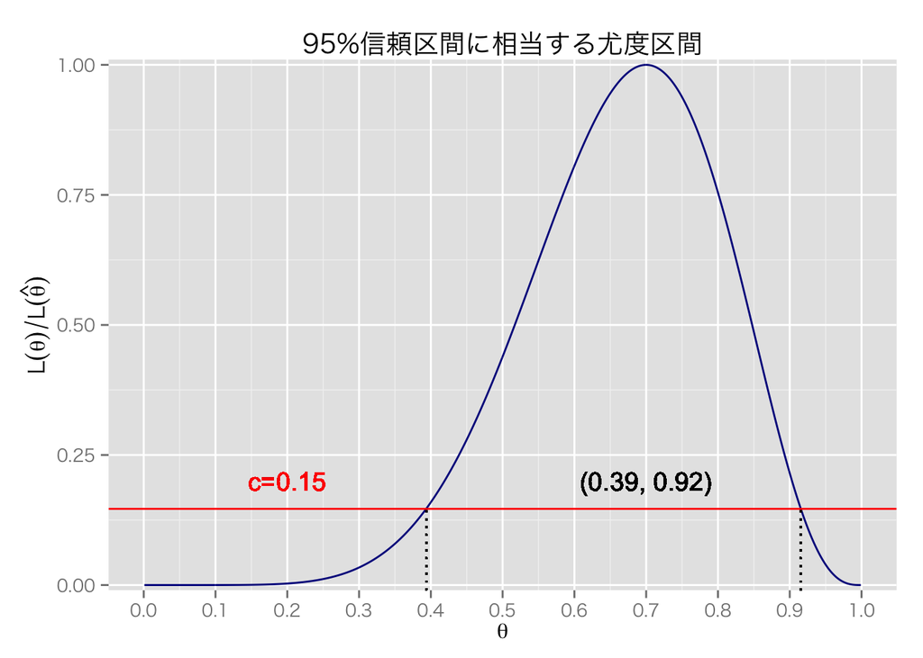

```r
p.1.5.95 <- ggplot(df1, aes(x=theta, y=likelihood.nml)) +
    geom_line(color="darkblue") +
    scale_x_continuous(breaks=seq(0, 1, by=.1)) +
    scale_y_continuous(expand=c(0, 0), limits=c(-0.01,1.01)) +
    geom_hline(yintercept=cutoff.05, color="red") +
    geom_segment(aes(x=lb.95, y= -0.01, xend=lb.95, yend=cutoff.05), linetype="dotted") +
    geom_segment(aes(x=ub.95, y= -0.01, xend=ub.95, yend=cutoff.05), linetype="dotted") +
    geom_text(x=0.2, y=0.2, label="c=0.15", color="red") +
    geom_text(x=0.7, y=0.2, label="(0.39, 0.92)") +
    labs(x=expression(theta), y=expression(L(theta)/L(hat(theta))),
         title="95%信頼区間に相当する尤度区間")
print(p.1.5.95)
```

### 問1-6

Wald統計量を求めるために、最尤推定値の標準誤差を計算すると、 $\mathrm{se}(\hat{\theta}) = I(\hat{\theta})^{-\frac{1}{2}} \approx 47.62^{-\frac{1}{2}} \approx 0.145$ となる。これを利用すると、$\theta_0=0.5$のWald統計量は、 $z = \frac{\hat{\theta} - \theta_0}{\mathrm{se}(\hat{\theta})} = \frac{0.7 - 0.5}{0.145} = 1.38,$ $|z| = 1.38 < 1.96$ である。

したがって、有意水準5%では、帰無仮説 $\theta_0=0.5$ は棄却されない。

### 問1-7

有意水準を5%に設定し、$\theta_0 = 0.5$ という帰無仮説がデータに整合的がどうかを考える場合は、どちらの推論も同じ結論に達する（結論：$\theta_0 = 0.5$ はデータと整合的である）。

## 問2

### 問2-1

この問題の尤度関数は、 $L(\theta) = \binom{100}{70} \theta^{70} (1-\theta)^{30}$ と書くことができる。

自分で関数を定義する場合、定数倍を無視して

```r
lik.2<- function(theta){
    likelihood <- theta^70 * (1 - theta)^30
    return(likelihood)
}
```

とすればよいが、`dbinom()` を利用してもよい。

$\theta$の取りうる範囲は$(0, 1)$なので、この範囲について尤度関数を図示すると、次のようになる。

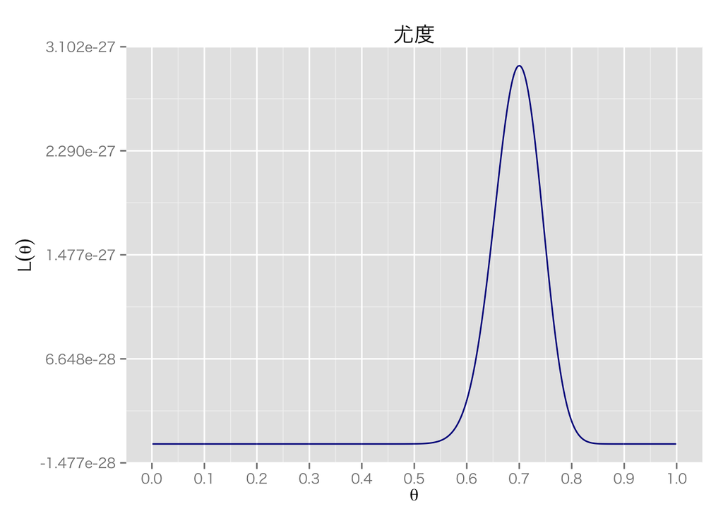

```r
## ggplot2 で図示するために、データフレームを作る
## thetaの範囲は厳密にいうと(0, 1)でないが、図示するには十分
df2 <- data.frame(theta = seq(0.001, 0.999, length=1000))
## それぞれのtheta の尤度を計算する
df2$likelihood <- lik.2(df2$theta)
## あるいは、
#df2$likelihood <- dbinom(x=70, size=100, prob=df2$theta)
## ggplot でグラフを作る
p2.1 <- ggplot(df2, aes(x=theta, y=likelihood)) + geom_line(color="darkblue") +
    scale_x_continuous(breaks=seq(0, 1, by=.1)) +
    labs(x=expression(theta), y=expression(L(theta)), title="尤度")
print(p2.1)
```

### 問2-2

定数項を省くと、対数尤度は、 $\log L(\theta) = 70\log \theta + 30 \log (1-\theta)$ となる。

既に$\theta \in (0, 1)$の尤度の値を計算したので、その値の自然対数を`log()`で計算し、対数尤度関数を図示する。

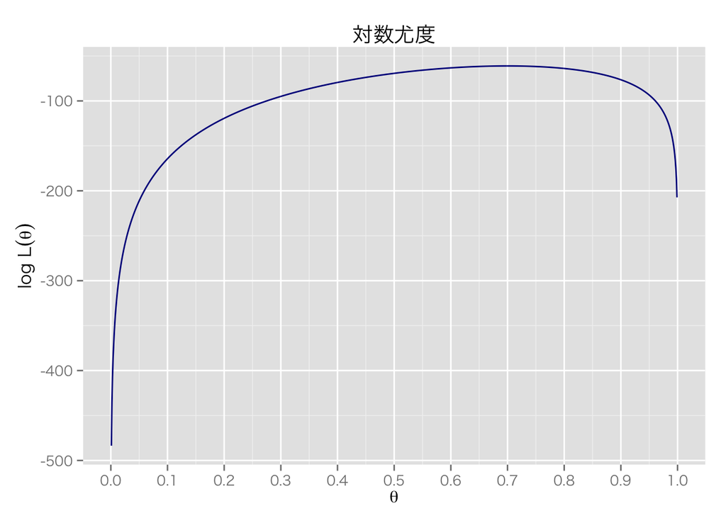

```r
df2$log.likelihood <- log(df2$likelihood)
p2.2 <- ggplot(df2, aes(x=theta, y=log.likelihood)) + geom_line(color="darkblue") +
    scale_x_continuous(breaks=seq(0, 1, by=.1)) +
    labs(x=expression(theta), y=expression(paste("log ",L(theta))), title="対数尤度")
print(p2.2)
```

### 問2-3

この問題のスコア関数は、 $S(\theta) = \frac{d}{d \theta} \log L(\theta) = \frac{70}{\theta} -\frac{30}{1-\theta}$ である。$S(\theta)=0$ を解くと、最尤推定値 $\hat{\theta} = \frac{7}{10} = 0.7$ を得る。 上に示したグラフ（尤度関数、対数尤度関数とも）からも、$\theta=0.7$で尤度が最大になることが確認できる。

### 問2-4

$I(\theta)$を得るために、対数尤度関数を2回微分してマイナス1をかけると、 $I(\theta) = -\frac{d^2}{d \theta^2} \log L(\theta) = \frac{70}{\theta^2} + \frac{30}{(1-\theta)^2}$ となる。したがって、フィッシャー情報量は、 $I(\hat{\theta}) = \frac{70}{0.7^2} + \frac{30}{(1-0.7)^2} \approx 476.19$ である。

### 問2-5

問1-5より、90%信頼区間、95%信頼区間に相当する尤度区間はそれぞれ、 $\left\{\theta: \frac{L(\theta)}{L(\hat{\theta})} > 0.26 \right\},$ $\left\{\theta: \frac{L(\theta)}{L(\hat{\theta})} > 0.15 \right\}$ であることがわかっている。

これらの条件を満たす $\theta$ の範囲を、Rで探してみよう。 まず、尤度を正規化する。

```r
df2$likelihood.nml <- df2$likelihood/lik.2(0.7)
```

次に、90%信頼区間に相当する $\theta$の範囲を探す。 上の結果より、正規化された尤度がcutoff.10$\approx 0.26$より大きい範囲の $\theta$ をみつければよい。

```r
## 指定した尤度区間に含まれるthetaを取り出す
theta.90 <- df1$theta[df2$likelihood.nml > cutoff.10]
## 指定した尤度区間に含まれるthetaの最小値と最大値を見つける
(lb.90 <- min(theta.90))
```

```
## [1] 0.6224
```

```r
(ub.90 <- max(theta.90))
```

```
## [1] 0.7712
```

したがって、90%信頼区間に相当する尤度区間は、おおよそ (0.62, 0.77) である。 これを図示しよう。

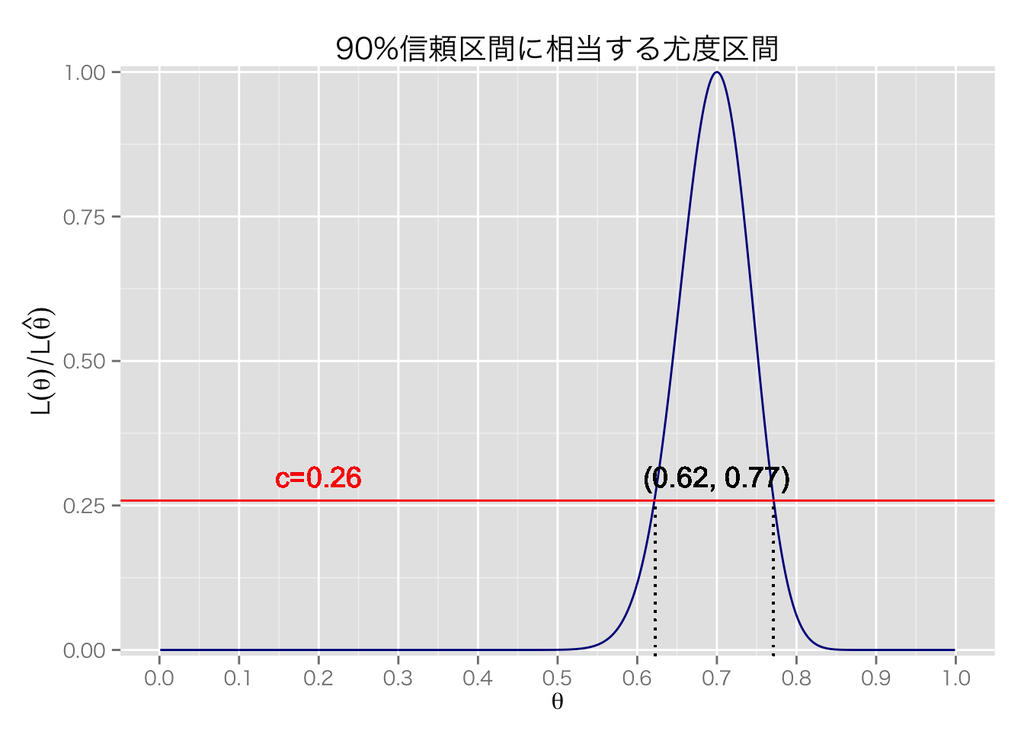

```r
p.2.5.90 <- ggplot(df2, aes(x=theta, y=likelihood.nml)) +
    geom_line(color="darkblue") +
    scale_x_continuous(breaks=seq(0, 1, by=.1)) +
    scale_y_continuous(expand=c(0, 0), limits=c(-0.01,1.01)) +
    geom_hline(yintercept=cutoff.10, color="red") +
    geom_segment(aes(x=lb.90, y= -0.01, xend=lb.90, yend=cutoff.10), linetype="dotted") +
    geom_segment(aes(x=ub.90, y= -0.01, xend=ub.90, yend=cutoff.10), linetype="dotted") +
    geom_text(x=0.2, y=0.3, label="c=0.26", color="red") +
    geom_text(x=0.7, y=0.3, label="(0.62, 0.77)") +
    labs(x=expression(theta), y=expression(L(theta)/L(hat(theta))),
         title="90%信頼区間に相当する尤度区間")
print(p.2.5.90)
```

同様に、95%信頼区間に相当する $\theta$の範囲を探す。 上の結果より、標準化された尤度がcutoff.05$\approx 0.15$より大きい範囲の $\theta$ をみつければよい。

```r
## 指定した尤度区間に含まれるthetaを取り出す
theta.95 <- df2$theta[df2$likelihood.nml > cutoff.05]
## 指定した尤度区間に含まれるthetaの最小値と最大値を見つける
(lb.95 <- min(theta.95))
```

```
## [1] 0.6064
```

```r
(ub.95 <- max(theta.95))
```

```
## [1] 0.7832
```

したがって、95%信頼区間に相当する尤度区間は、おおよそ (0.61, 0.78) である。 これを図示しよう。

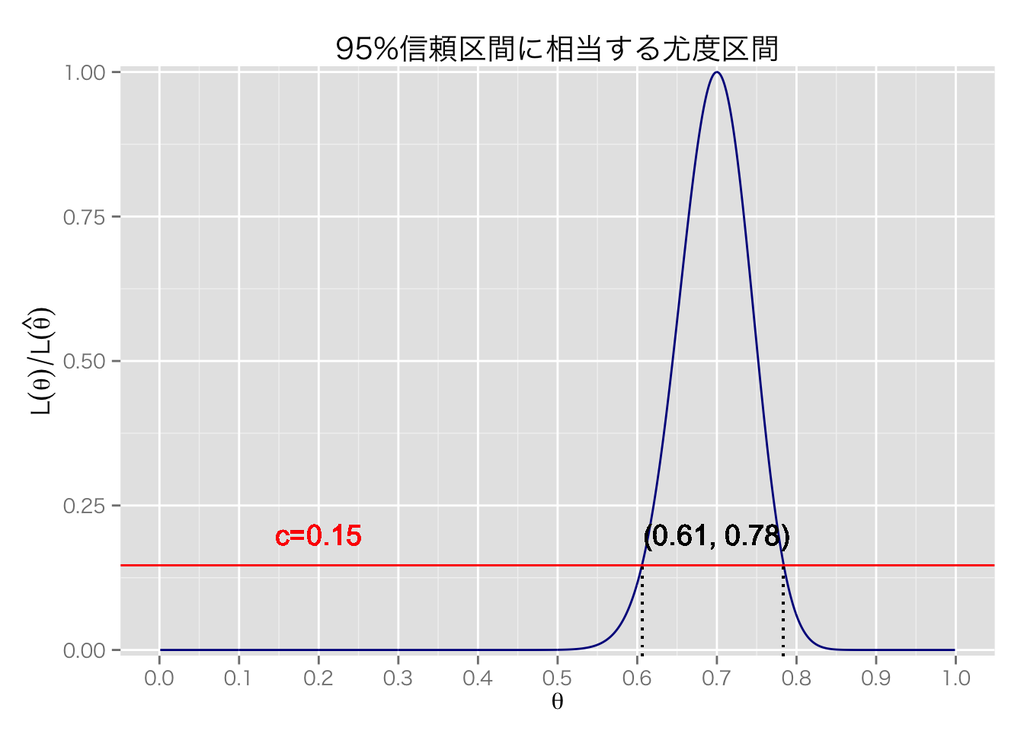

```r
p.2.5.95 <- ggplot(df2, aes(x=theta, y=likelihood.nml)) +
    geom_line(color="darkblue") +
    scale_x_continuous(breaks=seq(0, 1, by=.1)) +
    scale_y_continuous(expand=c(0, 0), limits=c(-0.01,1.01)) +
    geom_hline(yintercept=cutoff.05, color="red") +
    geom_segment(aes(x=lb.95, y= -0.01, xend=lb.95, yend=cutoff.05), linetype="dotted") +
    geom_segment(aes(x=ub.95, y= -0.01, xend=ub.95, yend=cutoff.05), linetype="dotted") +
    geom_text(x=0.2, y=0.2, label="c=0.15", color="red") +
    geom_text(x=0.7, y=0.2, label="(0.61, 0.78)") +
    labs(x=expression(theta), y=expression(L(theta)/L(hat(theta))),
         title="95%信頼区間に相当する尤度区間")
print(p.2.5.95)
```

### 問2-6

Wald統計量を求めるために、最尤推定値の標準誤差を計算すると、 $\mathrm{se}(\hat{\theta}) = I(\hat{\theta})^{-\frac{1}{2}} \approx 476.19^{-\frac{1}{2}} \approx 0.046$ となる。これを利用すると、$\theta_0=0.5$のWald統計量は、 $z = \frac{\hat{\theta} - \theta_0}{\mathrm{se}(\hat{\theta})} = \frac{0.7 - 0.5}{0.046} = 4.35,$ $|z| = 4.35 > 1.96$ である。

したがって、帰無仮説 $\theta_0=0.5$ は有意水準5%で棄却される。

### 問2-7

95%Wald信頼区間は、 $\hat{\theta} \pm 1.96\mathrm{se}(\hat{\theta}) = 0.7 \pm 1.96 \cdot 0.046 = (0.61, 0.79)$ と、なる。 先ほど求めた95%信頼区間に相当する尤度区間は (0.61, 0.78) だから、Wald信頼区間のほうが幅が広いが、その差は非常に小さい。 したがって、尤度区間に基づく推論も、Wald統計量（Wald信頼区間）に基づく推論も、ほぼ同じ結論に至るはずである。

実際、有意水準を5%に設定し、$\theta_0 = 0.5$ という帰無仮説がデータに整合的がどうかを考えたとき、どちらの推論も同じ結論に達する（結論：$\theta_0 = 0.5$ はデータと整合的ではない）。

問3の解答は略。

授業の内容に戻る